# Assignment 8: Spatial Analysis in R

Melissa Merritt

## OVERVIEW

This exercise accompanies the lessons in Environmental Data Analytics (ENV872L) on spatial analysis.

## Directions

1. Rename this file `<FirstLast>_A02_CodingBasics.Rmd` (replacing `<FirstLast>` with your first and last name).
2. Change “Student Name” on line 3 (above) with your name.
3. Use the lesson as a guide. It contains code that can be modified to complete the assignment.
4. Work through the steps, **creating code and output** that fulfill each instruction.
5. Be sure to **answer the questions** in this assignment document. Space for your answers is provided in this document and is indicated by the “>” character. If you need a second paragraph be sure to start the first line with “>”. You should notice that the answer is highlighted in green by RStudio.
6. When you have completed the assignment, **Knit** the text and code into a single HTML file.

## DATA WRANGLING

### Set up your session

1. Check your working directory
2. Import libraries: tidyverse, sf, leaflet, and mapview

```r
#1.
getwd() #check working directory
```

```
## [1] "/home/guest/Documents/EDA-Fall2022"
```

```r
#2.

library(tidyverse)
library(sf)
```

```r
library(leaflet)
library(mapview)

#library() function to import packages
```

### Read (and filter) county features into an sf dataframe and plot

In this exercise, we will be exploring stream gage height data in Nebraska corresponding to floods occurring there in 2019. First, we will import from the US Counties shapefile we’ve used in lab lessons, filtering it this time for just Nebraska counties. Nebraska’s state FIPS code is `31` (as North Carolina’s was `37`).

3. Read the `cb_2018_us_county_20m.shp` shapefile into an sf dataframe, filtering records for Nebraska counties (State FIPS = 31)
4. Reveal the dataset’s coordinate reference system
5. Plot the records as a map (using `mapview` or `ggplot`)

```r
#3. Read in Counties shapefile into an sf dataframe, filtering for just NE counties
Nebraska_counties <- st_read("./Data/Spatial/cb_2018_us_county_20m.shp") %>%
  filter(STATEFP == 31)
# Use st_read() to import the data file into an sf dataframe. Use filter() to only keep Nebraska counties.

#4. Reveal the CRS of the counties features

st_crs(Nebraska_counties)
```

```
## Coordinate Reference System:
##   User input: NAD83
##   wkt:
## GEOGCRS["NAD83",
##     DATUM["North American Datum 1983",
##         ELLIPSOID["GRS 1980",6378137,298.257222101,
##             LENGTHUNIT["metre",1]]],
##     PRIMEM["Greenwich",0,
##         ANGLEUNIT["degree",0.0174532925199433]],
##     CS[ellipsoidal,2],
##         AXIS["latitude",north,
##             ORDER[1],
##             ANGLEUNIT["degree",0.0174532925199433]],
##         AXIS["longitude",east,
##             ORDER[2],
##             ANGLEUNIT["degree",0.0174532925199433]],
##     ID["EPSG",4269]]
```

```r
# Use st_crs() to show that the coordinate reference system is NAD83.

#5. Plot the data

mapview(Nebraska_counties)
```

[interactive chart not shown]

```r
# Use mapview() function to plot the data on a map.
```

6. What is the EPSG code of the Counties dataset? Is this a geographic or a projected coordinate reference system? (Or, does this CRS use angular or planar coordinate units?) To what datum is this CRS associated? (Tip: look the EPSG code on https://spatialreference.org)

> ANSWER: The EPSG code of the Counties dataset is 4269. This is a geographic coordinate reference system (angular coordinate units). The Datum is North American Datum 1983.

### Read in gage locations csv as a dataframe, then display the column names it contains

Next we’ll read in some USGS/NWIS gage location data added to the `Data/Raw` folder. These are in the `NWIS_SiteInfo_NE_RAW.csv` file.(See `NWIS_SiteInfo_NE_RAW.README.txt` for more info on this dataset.)

7. Read the NWIS_SiteInfo_NE_RAW.csv file into a standard dataframe.
8. Display the column names of this dataset.

```r
#7. Read in gage locations csv as a dataframe

Gage_data <- read.csv("./Data/Raw/NWIS_SiteInfo_NE_RAW.csv")

# we can use read.csv() function to import the data.

#8. Reveal the names of the columns

colnames(Gage_data) #use to see the column names
```

```
## [1] "site_no"            "station_nm"         "site_tp_cd"
## [4] "dec_lat_va"         "dec_long_va"        "coord_acy_cd"
## [7] "dec_coord_datum_cd"
```

9. What columns in the dataset contain the x and y coordinate values, respectively?  
   > ANSWER: The dec_long_va and dec_lat_va columns are the x and y coordinate values, respectively.

### Convert the dataframe to a spatial features (“sf”) dataframe

10. Convert the dataframe to an sf dataframe.
- Note: These data use the same coordinate reference system as the counties dataset
11. Display the column names of the resulting sf dataframe

```r
#10. Convert to an sf object
Gage_data_sf <- st_as_sf(Gage_data, coords = c('dec_long_va', 'dec_lat_va'), crs=4269)

# We can use the st_as_sf() function to convert the dataframe to an sf dataframe. We need to specify the spatial data (longitude and latitude) with the coords = argument. Since it is the same coordinate system, we can use crs=4269.

#11. Re-examine the column names

colnames(Gage_data_sf) #use to see each column name.
```

```
## [1] "site_no"            "station_nm"         "site_tp_cd"
## [4] "coord_acy_cd"       "dec_coord_datum_cd" "geometry"
```

12. What new field(s) appear in the sf dataframe created? What field(s), if any, disappeared?

> ANSWER: The new field that appeared is the geometry column that contains the spatial data. The fields that disappeared are the dat_lat_va and the dat_long_va because these fields were combined to create the geometry field.

### Plot the gage locations on top of the counties

13. Use `ggplot` to plot the county and gage location datasets.
- Be sure the datasets are displayed in different colors
- Title your plot “NWIS Gage Locations in Nebraska”
- Subtitle your plot with your name

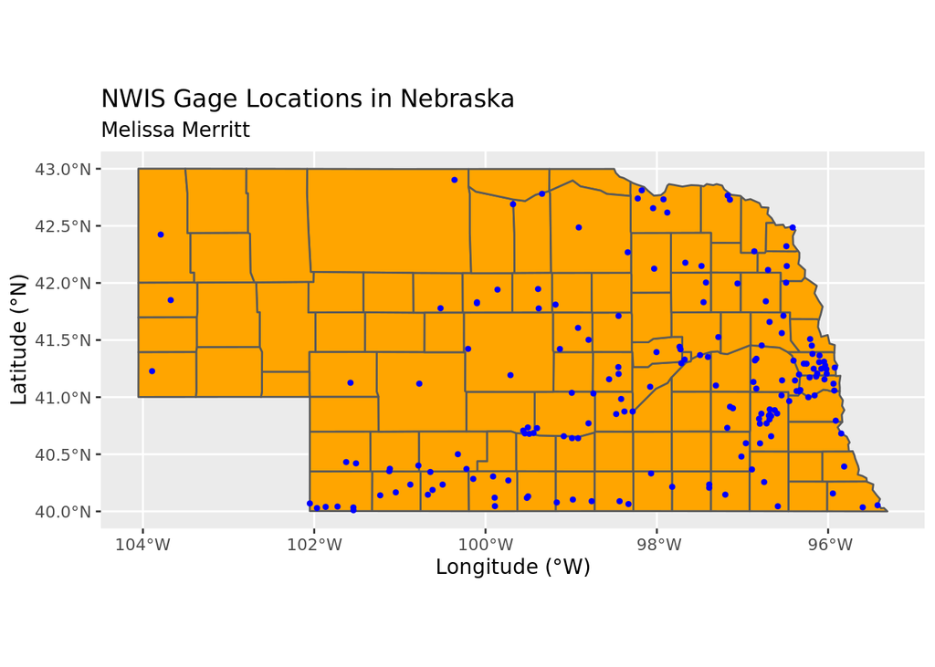

```r
#13. Plot the gage locations atop the county features

gage_locations_plot <- ggplot() +
  geom_sf(data = Nebraska_counties, fill = 'orange') +
  geom_sf(data = Gage_data_sf, color = 'blue', size = 0.9) +
  labs(title = "NWIS Gage Locations in Nebraska") +
  labs(subtitle = "Melissa Merritt") +
  xlab("Longitude (°W)") +
  ylab("Latitude (°N)")
print(gage_locations_plot)
```

```r
# We can use the ggplot() function to plot the county and gage location datasets. Using the geom_sf() function we can define the data we are using along with colors to show the contrast. It is important to have the gage sites data above the counties data, so it overlays on the display. Using the lab(), xlab(), and ylab() functions we can label the map and the axes, respectively. Then we can use the print() function to see the map display.
```

### Read in the gage height data and join the site location data to it.

Lastly, we want to attach some gage height data to our site locations. I’ve constructed a csv file listing many of the Nebraska gage sites, by station name and site number along with stream gage heights (in meters) recorded during the recent flood event. This file is titled `NWIS_SiteFlowData_NE_RAW.csv` and is found in the Data/Raw folder.

14. Read the `NWIS_SiteFlowData_NE_RAW.csv` dataset in as a dataframe.
15. Show the column names .
16. Join our site information (already imported above) to these gage height data.
- The `site_no` and `station_nm` can both/either serve as joining attributes.
- Construct this join so that the result only includes spatial features where both tables have data.
17. Show the column names in this resulting spatial features object
18. Show the dimensions of the resulting joined dataframe

```r
#14. Read the site flow data into a data frame

gage_height_data <- read.csv("./Data/Raw/NWIS_SiteFlowData_NE_RAW.csv")

# Using the read.csv() function we can read the raw dataset in as a dataframe.


#15. Show the column names

colnames(gage_height_data) #use to check column names.
```

```
## [1] "site_no"    "station_nm" "date"       "gage_ht"
```

```r
#16. Join the flow data to our NWIS gage location spatial dataframe

gage_data_join <- merge(x = Gage_data_sf,
                        y = gage_height_data,
                        by.x = "site_no",
                        by.y = "site_no")

# We can use the the merge() function to combine the two dataframes shown in the "x =" and "y =" arguments. The by.x= and by.y= arguments let us define the attributes we want to use to join the data. Merge only includes spatial features where both tables have data.


#17. Show the column names of the joined dataset

colnames(gage_data_join) #use to check column names.
```

```
## [1] "site_no"            "station_nm.x"       "site_tp_cd"
## [4] "coord_acy_cd"       "dec_coord_datum_cd" "station_nm.y"
## [7] "date"               "gage_ht"            "geometry"
```

```r
#18. Show the dimensions of this joined dataset

dim(gage_data_join)
```

```
## [1] 136   9
```

```r
#we can use the dim() function to check the dimensions of the dataset.
```

### Map the pattern of gage height data

Now we can examine where the flooding appears most acute by visualizing gage heights spatially. 19. Plot the gage sites on top of counties (using `mapview`, `ggplot`, or `leaflet`) * Show the magnitude of gage height by color, shape, other visualization technique.

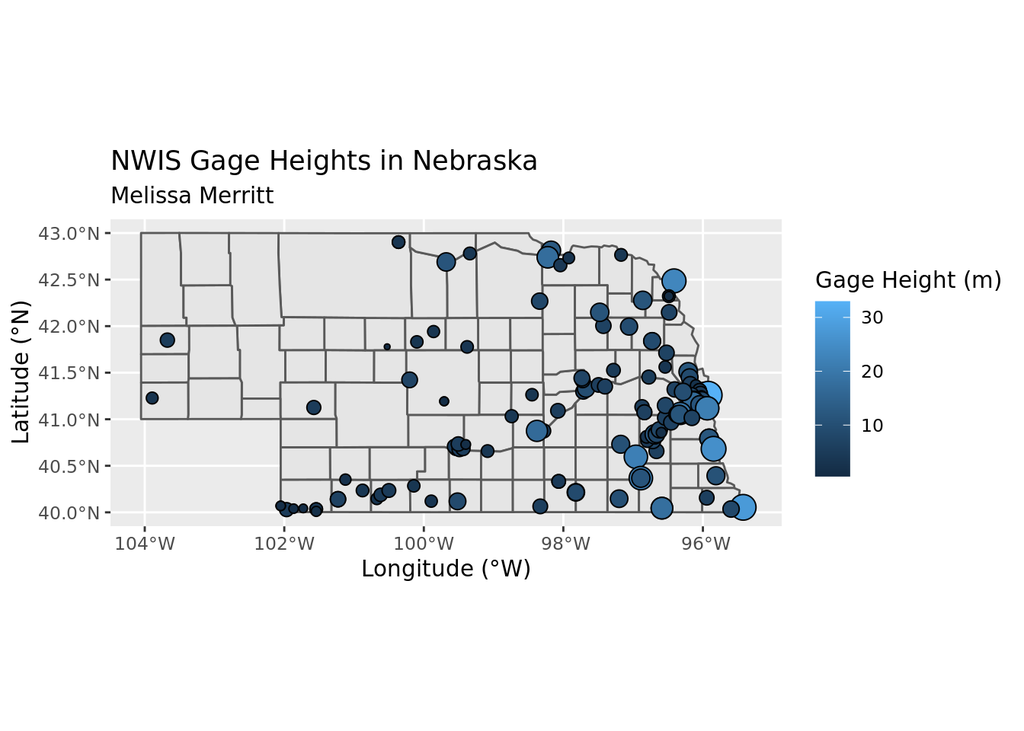

```r
#Map the points, sized by gage height

gage_height_plot <- ggplot() +
  geom_sf(data = Nebraska_counties) +
  geom_sf(data = gage_data_join, aes(size = gage_data_join$gage_ht, fill = gage_data_join$gage_ht), pch = 21) +
  guides(size = FALSE) +
  labs(fill = "Gage Height (m)") +
  xlab("Longitude (°W)") +
  ylab("Latitude (°N)") +
  labs(title = "NWIS Gage Heights in Nebraska") +
  labs(subtitle = "Melissa Merritt")
print(gage_height_plot)
```

```r
# To create this map, we can use the ggplot() function. Within ggplot we can use the geom_sf() functions to plot both data sets spatially. For the gage data points, we can use the aes() function to change the size to be based on gage height and the color to be based on gage height. pch=21 makes the points able to fill with a color. We can use the guides() function to take away the second legend that was repetitive. We can use the labs() function to label the legend, the title, and the subtitle. We can then use the xlab and ylab functions to label the x and y axes respectively. Lastly, we can use the print() function to view the plot.
```

## SPATIAL ANALYSIS

Up next we will do some spatial analysis with our data. To prepare for this, we should transform our data into a projected coordinate system. We’ll choose UTM Zone 14N (EPGS = 32614).

### Transform the counties and gage site datasets to UTM Zone 14N

20. Transform the counties and gage sf datasets to UTM Zone 14N (EPGS = 32614).
21. Using `mapview` or `ggplot`, plot the data so that each can be seen as different colors

```r
#20 Transform the counties and gage location datasets to UTM Zone 14

gage_data_utm <- st_transform(gage_data_join, crs = 32614)
NE_counties_utm <- st_transform(Nebraska_counties, crs = 32614)

# To transform the datasets into a UTM coordinate reference system, we can use the st_transform() function, and clarify that the crs we want is the EPGS code 32614.

#21 Plot the data

mapview(gage_data_utm,
        col.regions = "blue",
        cex = 3) +
  mapview(NE_counties_utm,
          col.regions = "gray")
```

[interactive chart not shown]

```r
# We can use the mapview function to plot the gage data in UTM over the county data in UTM. We can use the col.regions = argument to change the colors, and the cex = argument to change the size of the points.
```

### Select the gages falling within a given county

Now let’s zoom into a particular county and examine the gages located there. 22. Select Lancaster county from your projected county sf dataframe 23. Select the gage sites falling `within` that county * Use either matrix subsetting or tidy filtering 24. Create a plot showing: * all Nebraska counties, * the selected county, * and the gage sites in that county

```r
#22 Select the county

Lancaster_county <- NE_counties_utm %>%
  filter(NAME == 'Lancaster')

# To select just Lancaster county, we can use the filter() function within a pipe (%>%) to specificy by the name column.

#23 Select gages within the selected county

Gage_lancaster_intersect <- gage_data_utm[Lancaster_county,]

# To chose the sites within Lancaster, we can use a matrix to subset the data.

#24 Plot
mapview(NE_counties_utm, col.regions = "gray",
        alpha.regions = 1) +
mapview(Lancaster_county, col.regions = "pink",
        alpha.regions = 1) +
mapview(Gage_lancaster_intersect, col.regions = "blue",
          cex = 2)
```

[interactive chart not shown]

```r
# To create the zoom in map to Lancaster county, we can layer with mapview. For the first layer we use the counties dataset. The second layer is the Lancaster county polygon. The third layer is the locations of the gage sites within Lancaster county. We can use alpha.regions to change the transparency. We can use col.regions to change the colors, and cex can change the size of the points.
```